# Risk Factor Analysis

## Outcome Variable

**Outcome Variable:** haz

## Predictor Variables

**Intervention Variable:** mhtcm

**Adjustment Set:**

- arm
- W_mage
- meducyrs
- feducyrs
- hhwealth_quart
- single
- delta_W_mage
- delta_meducyrs
- delta_feducyrs
- delta_hhwealth_quart
- delta_single

## Stratifying Variables

The analysis was stratified on these variable(s):

- agecat

## Data Summary

| agecat | mhtcm | n_cell | n | outcome_variable |
| --- | --- | --- | --- | --- |
| Birth | >=155 cm | 27809 | 56682 | haz |
| Birth | <151 cm | 18830 | 56682 | haz |
| Birth | [151-155) cm | 10043 | 56682 | haz |
| 6 months | >=155 cm | 27236 | 52747 | haz |
| 6 months | <151 cm | 16160 | 52747 | haz |
| 6 months | [151-155) cm | 9351 | 52747 | haz |
| 24 months | >=155 cm | 10000 | 24425 | haz |
| 24 months | <151 cm | 9489 | 24425 | haz |
| 24 months | [151-155) cm | 4936 | 24425 | haz |

The following strata were considered:

- agecat: 24 months
- agecat: 6 months
- agecat: Birth

## Methods Detail

We’re interested in the causal parameters $E[Y_a]$ for all values of $a \in \mathcal{A}$. These parameters represent the mean outcome if, possibly contrary to fact, we intervened to set all units to have $A=a$. Under the randomization and positivity assumptions, these are identified by the statistical parameters $\psi_a=E_W[E_{Y|A,W}(Y|A=a,W)]$. In addition, we’re interested in the mean of $Y$, $E[Y]$ under no intervention (the observed mean). We will estimate these parameters by using SuperLearner to fit the relevant likelihood factors – $E_{Y|A,W}(Y|A=a,W)$ and $p(A=a|W)$, and then updating our likelihood fit using a joint TMLE.

For unadjusted analyses ($W=\{\}$), initial likelihoods were estimated using Lrnr_glm to estimate the simple $E(Y|A)$ and Lrnr_mean to estimate $p(A)$. For adjusted analyses, a small library containing Lrnr_glmnet, Lrnr_xgboost, and Lrnr_mean was used.

Having estimated these parameters, we will then use the delta method to estimate relative risks and attributable risks relative to a prespecified baseline level of $A$.

# Results Detail

## Results Plots

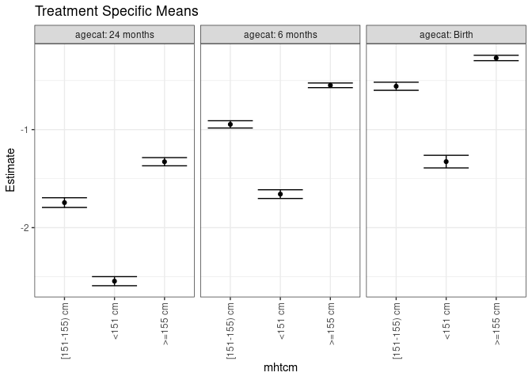

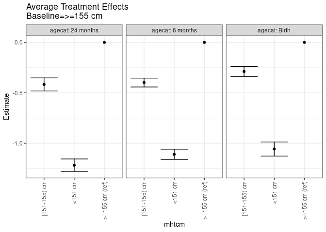

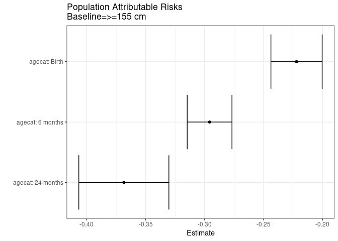

## Results Table

### Parameter: TSM

| agecat | intervention_level | baseline_level | estimate | ci_lower | ci_upper |
| --- | --- | --- | --- | --- | --- |
| Birth | >=155 cm | NA | -0.2695681 | -0.2968794 | -0.2422569 |
| Birth | <151 cm | NA | -1.3266624 | -1.3909649 | -1.2623598 |
| Birth | [151-155) cm | NA | -0.5579543 | -0.5992024 | -0.5167063 |
| 6 months | >=155 cm | NA | -0.5484062 | -0.5720588 | -0.5247535 |
| 6 months | <151 cm | NA | -1.6583205 | -1.7027543 | -1.6138866 |
| 6 months | [151-155) cm | NA | -0.9467021 | -0.9837899 | -0.9096143 |
| 24 months | >=155 cm | NA | -1.3277563 | -1.3694247 | -1.2860878 |
| 24 months | <151 cm | NA | -2.5462292 | -2.5926288 | -2.4998296 |
| 24 months | [151-155) cm | NA | -1.7448370 | -1.7944681 | -1.6952059 |

### Parameter: E(Y)

| agecat | intervention_level | baseline_level | estimate | ci_lower | ci_upper |
| --- | --- | --- | --- | --- | --- |
| Birth | NA | NA | -0.4916492 | -0.5085939 | -0.4747045 |
| 6 months | NA | NA | -0.8442210 | -0.8603144 | -0.8281276 |
| 24 months | NA | NA | -1.6962480 | -1.7185750 | -1.6739211 |

### Parameter: ATE

| agecat | intervention_level | baseline_level | estimate | ci_lower | ci_upper |
| --- | --- | --- | --- | --- | --- |
| Birth | >=155 cm | >=155 cm | 0.0000000 | 0.0000000 | 0.0000000 |
| Birth | <151 cm | >=155 cm | -1.0570943 | -1.1269039 | -0.9872846 |
| Birth | [151-155) cm | >=155 cm | -0.2883862 | -0.3376782 | -0.2390942 |
| 6 months | >=155 cm | >=155 cm | 0.0000000 | 0.0000000 | 0.0000000 |
| 6 months | <151 cm | >=155 cm | -1.1099143 | -1.1603780 | -1.0594506 |
| 6 months | [151-155) cm | >=155 cm | -0.3982960 | -0.4422958 | -0.3542962 |
| 24 months | >=155 cm | >=155 cm | 0.0000000 | 0.0000000 | 0.0000000 |
| 24 months | <151 cm | >=155 cm | -1.2184729 | -1.2814711 | -1.1554747 |
| 24 months | [151-155) cm | >=155 cm | -0.4170808 | -0.4820970 | -0.3520645 |

### Parameter: PAR

| agecat | intervention_level | baseline_level | estimate | ci_lower | ci_upper |
| --- | --- | --- | --- | --- | --- |
| Birth | >=155 cm | NA | -0.2220811 | -0.2437995 | -0.2003627 |
| 6 months | >=155 cm | NA | -0.2958149 | -0.3147910 | -0.2768387 |
| 24 months | >=155 cm | NA | -0.3684918 | -0.4066716 | -0.3303119 |